# conger

## Initial data inspection

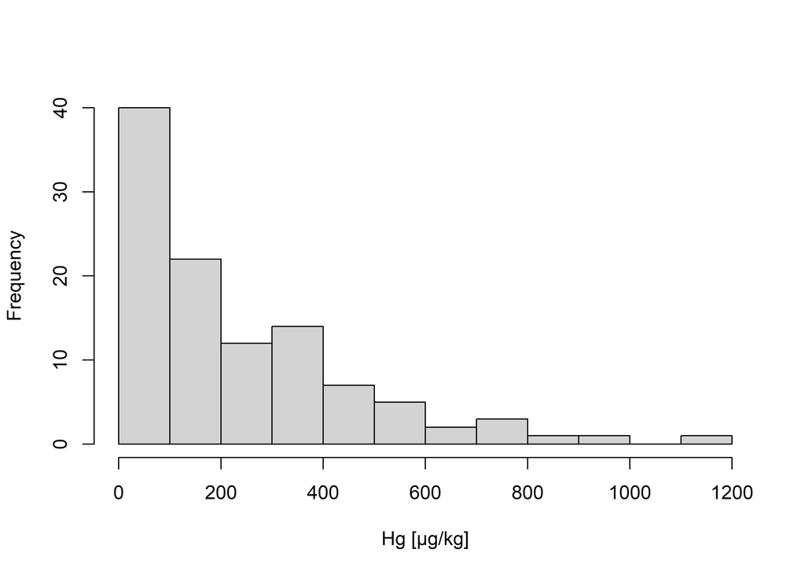

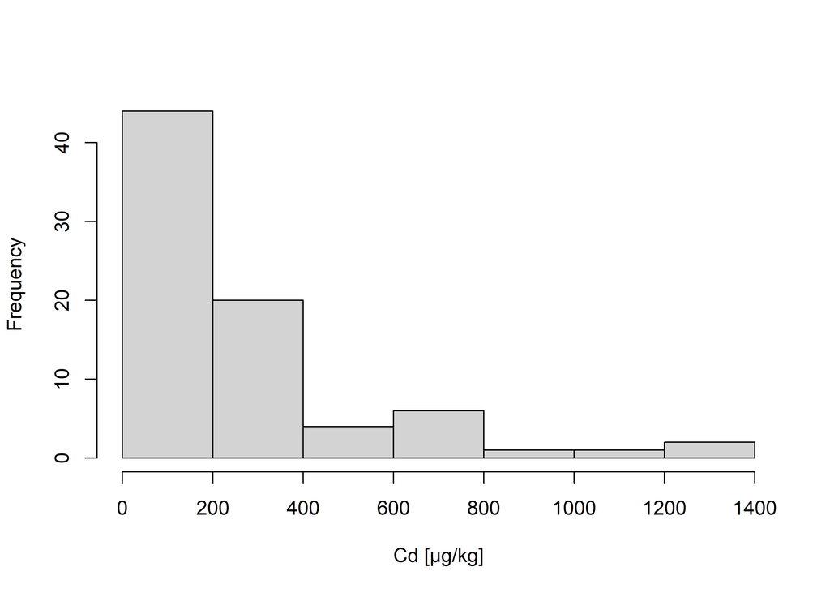

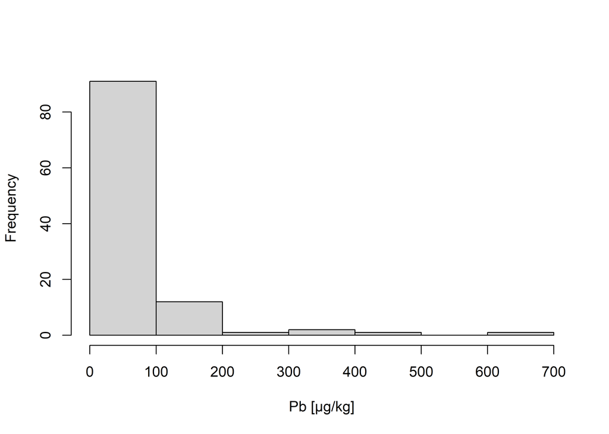

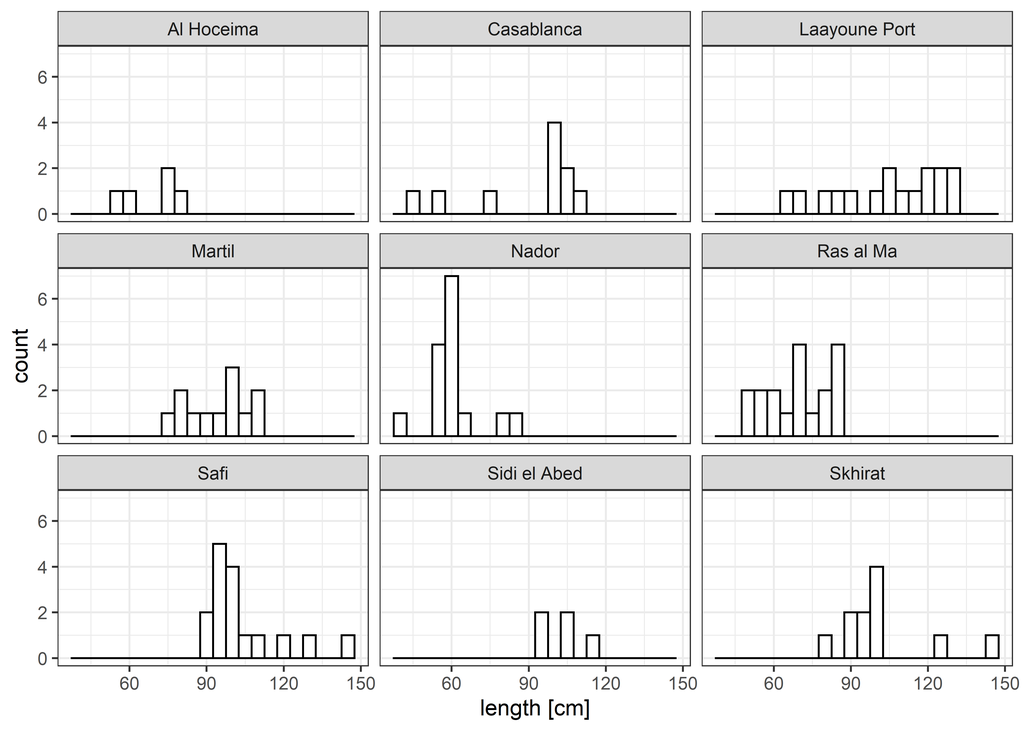

**Fig 1** Overview of data distribution

## Plotting the model results

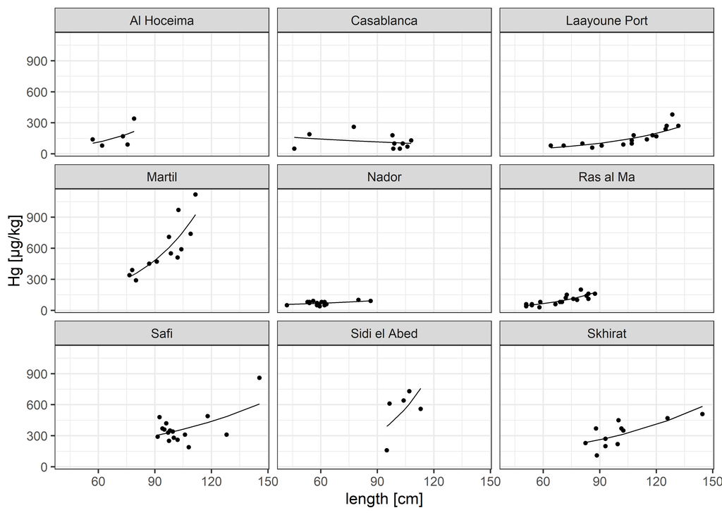

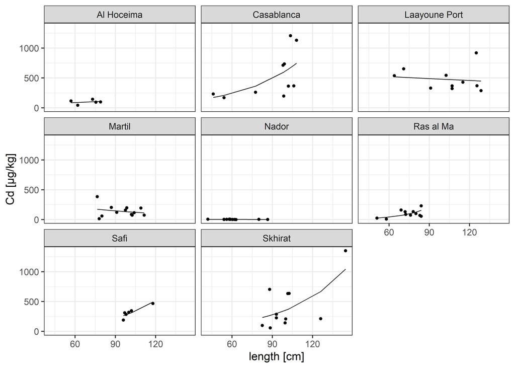

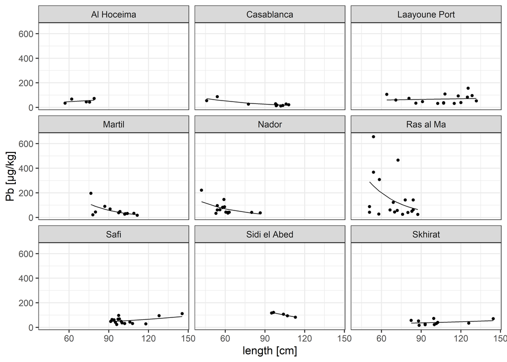

**Fig 2a** Raw data and GLM predictions of contaminat levels in Conger per Station as panel

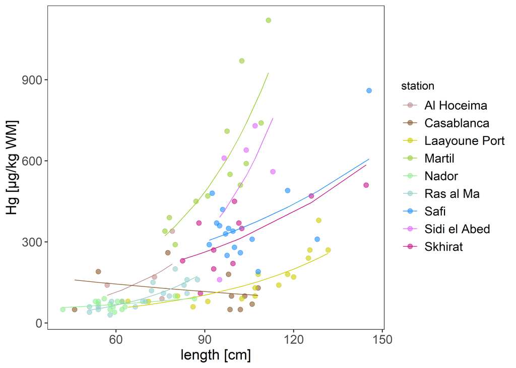

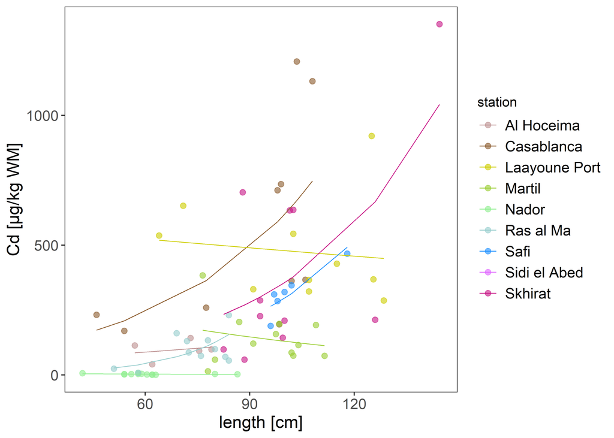

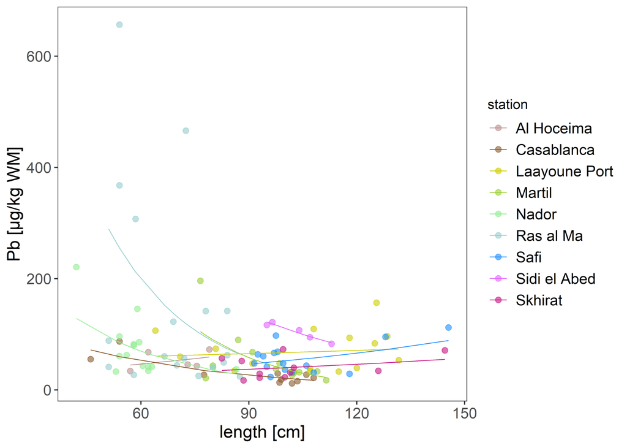

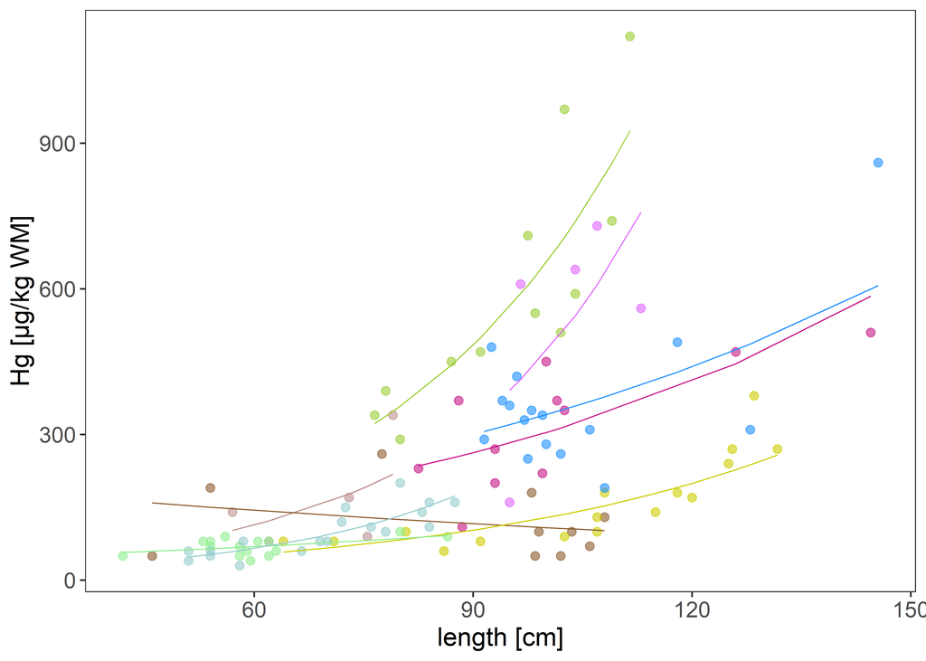

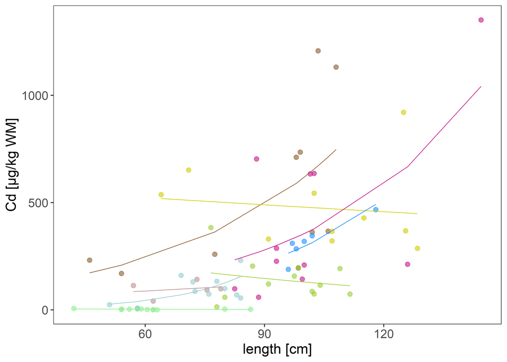

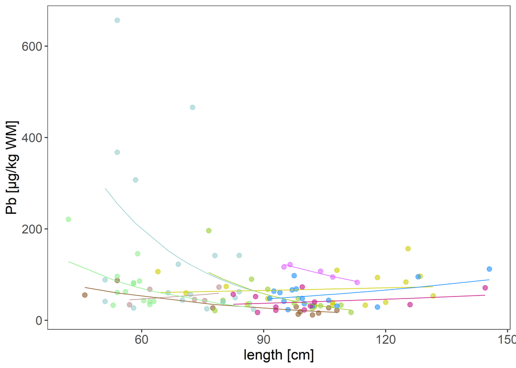

**Fig 2b** Raw data and GLM predictions of contaminat levels in COnger in single graph  
**Tab 1** Model statistics, all values are provided on the log scale. Estimate for “station” provides the y-Intercept (i.e. contaminant load for a given station when length is 0) per station; significance indicates different from 0. Estimates of “station:length” provide the effect of length for this station (i.e. the change in contaminant load for an increase of one unit in length); significance indicates whether the effect is different from 0 at this station (i.e. the slope of contamination load over length at this station is significantly different from 0).

| Hg_Coefficient | Estimate | std_error | t_value | p_value |
| --- | --- | --- | --- | --- |
| stationAl Hoceima | 2.683 | 1.243 | 2.159 | 0.034 |
| stationCasablanca | 5.399 | 0.456 | 11.849 | 0.000 |
| stationLaayoune Port | 2.655 | 0.439 | 6.040 | 0.000 |
| stationMartil | 3.474 | 0.794 | 4.376 | 0.000 |
| stationNador | 3.592 | 0.514 | 6.992 | 0.000 |
| stationRas al Ma | 2.054 | 0.461 | 4.455 | 0.000 |
| stationSafi | 4.568 | 0.619 | 7.380 | 0.000 |
| stationSidi el Abed | 2.477 | 2.306 | 1.074 | 0.286 |
| stationSkhirat | 4.250 | 0.598 | 7.108 | 0.000 |
| stationAl Hoceima:length | 0.034 | 0.018 | 1.922 | 0.058 |
| stationCasablanca:length | -0.007 | 0.005 | -1.440 | 0.153 |
| stationLaayoune Port:length | 0.022 | 0.004 | 5.357 | 0.000 |
| stationMartil:length | 0.030 | 0.008 | 3.622 | 0.000 |
| stationNador:length | 0.011 | 0.008 | 1.283 | 0.203 |
| stationRas al Ma:length | 0.035 | 0.007 | 5.417 | 0.000 |
| stationSafi:length | 0.013 | 0.006 | 2.151 | 0.034 |
| stationSidi el Abed:length | 0.037 | 0.022 | 1.647 | 0.103 |
| stationSkhirat:length | 0.015 | 0.006 | 2.535 | 0.013 |